# Data Analysis :

#### Navigation :

> You can navigate through this slideshow using the board appears at the bottom-right corner, or by using the keyboard arrows.  
> You can click on any graph to show the code used to produce it.

# Dataset overview :

## Done by :

> Mina Karam  
> (Data Analyist)

# Investigation overview :

## Investigation :

The analysis process will focus on fundamental aspects of the data answering obvious questions and through the presentation progress, we will be answering more complex questions.

Some of these questions are:

> Which year, month and day were the busiest for airflights ?  
> what are the major air lines and their contribution through the years ?  
> What is the relation between departure and arrival Delay?  
> what are the main reasons for airflights postponing ?  
> and more...

## Visualization 1:

## Airflight counts through the years

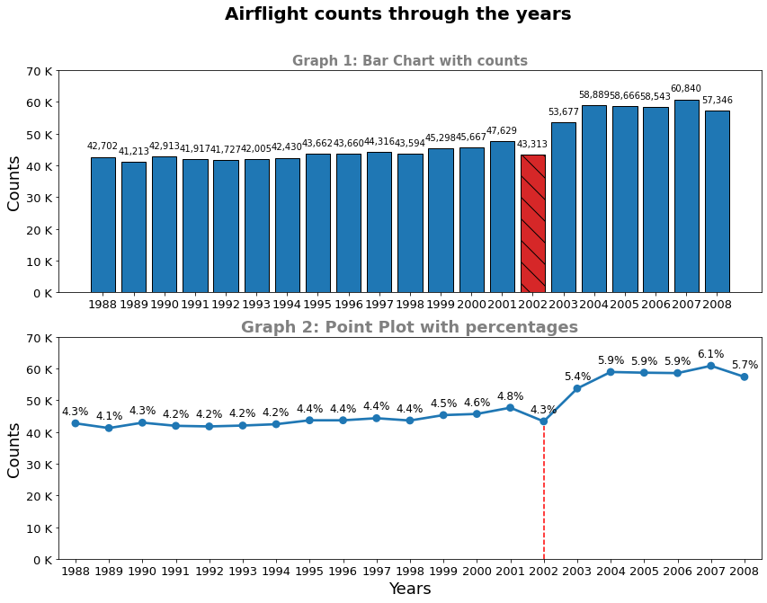

> Observation :  
> The Graph shows a plateau till year(1993) then a slight increase in flights with an interesting drop at year(2002) that need further investigation.

## Visualization 2:

## Airflight counts through the years (showing months)

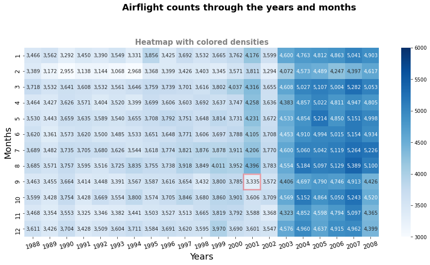

> Note :  
> This Heat map shows counts in both written numbers and colored densities (check the color bar next to the graph).

> Observation :  
> The Graph confirms the previous findings, here we see a clear sudden decline in airflights (year: 2001, month: 9) due to the (9/11) attacks. This decline continues through the rest of the year and the following one with back-to-normal counts starting from (year 2003) and healthy gradual increase in the following years.

## Visualization 3:

## Airflight counts through the months and days

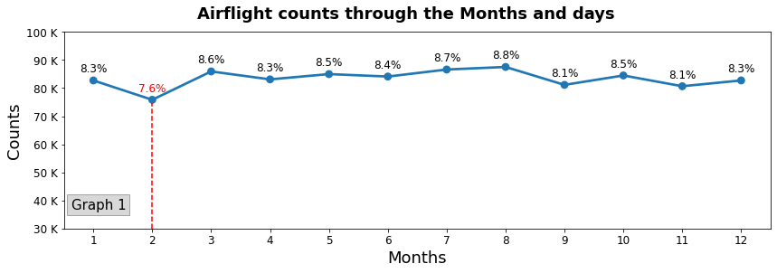

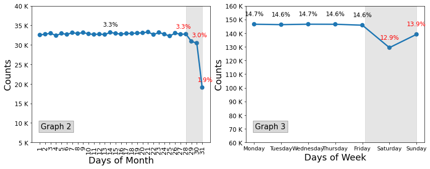

> Observations :  
> Graph 1 shows a slight decrease in Feb flights which is insignificant and can be explained by the fact that this month is shorter in days in comparison with other months.

> Graph 2 shows a slight decrease in flights within the last few days of the month. the decrease is insignificant.

> Graph 3 shows a slight decrease in flights in Saturdays and Sundays which can be explained by the fact that these days are vacation days in U.S.A.

## Visualization 4:

## The Top and Bottom 5 Airlines

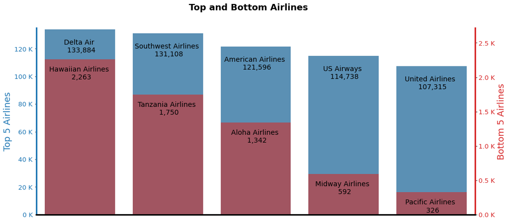

> Note :  
> Combined Bar Chart (common x-axis) shows both Top and Bottom airlines, check the appropriate y-axis for each set.

> Observations :  
> The Graph shows that Delta airline is the most common airline used in travels while Pacific airlines is the least common.  
> but what about the top 5 contribution among the rest of airlines, further investigation is followed.

## Visualization 5:

## The Top 5 Airlines contributions among the rest of Airlines

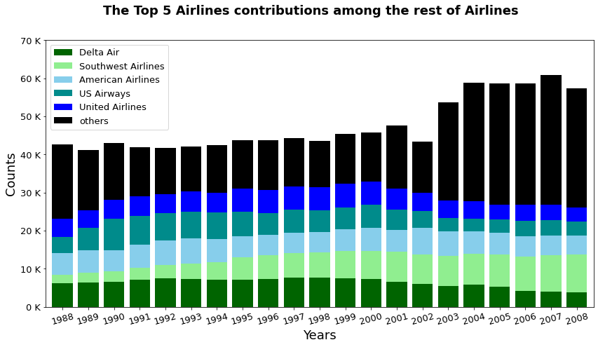

> Observations :  
> The Graph shows that top airlines contribution increased till year(2000) then a decline is observed in the following years with a plateau from year(2003) forward.

> The contribution of the top airlines change over the years, the first obvious observation is that southwest airlines contribution increases over the years and it may be the dominant in the late years, American airlines progress seems in a plateau phase with no major changes, all other 3 airlines are in a decline phase and that can be explained by the rapid growth of new airlines espicially in the late years.

## Visualization 6:

## The flights distances distribution

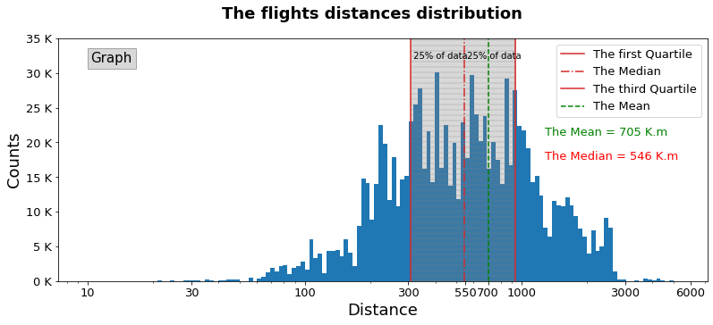

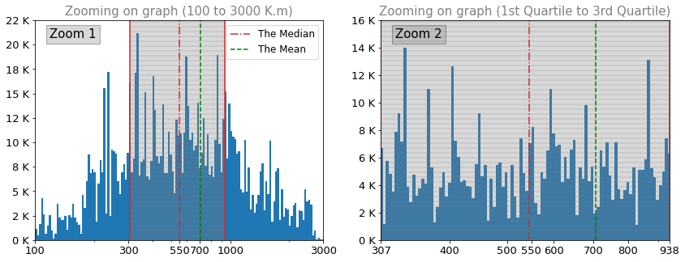

> Note :  
> The histogram is performed on a logarithmic scale.

> Observations :  
> The Graph shows a wide range of distrubtion from 20 to 5000 K.m., the average of distances traveled is about(700 K.m), while 50% of flights are above (550 K.m) and 50% are below that.

> The zoom graphs shows 3 peaks at (350, 410, 870 K.m) that exceed 12,000 flights, they seem to represent a specific heavy duty airline routes.

## Visualization 7:

## The flights distances distribution over the years

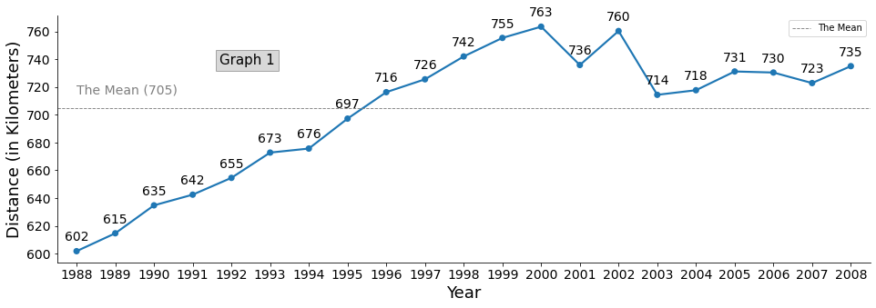

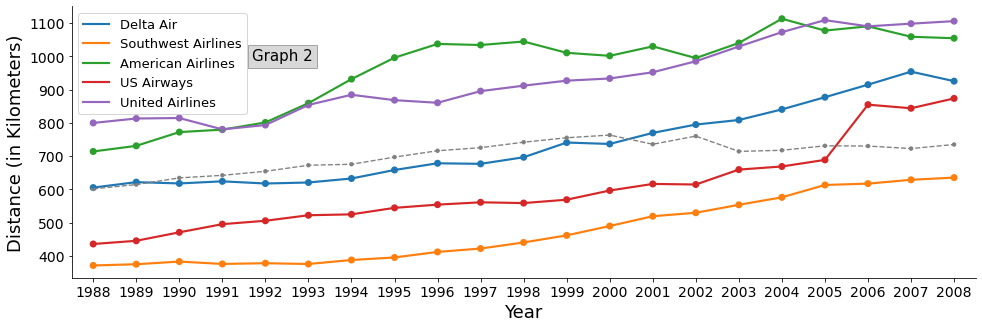

> Note :  
> Graph 1 shows average airflight distances through the years, Graph 2 shows top 5 airlines flight distances.

> Observations :  
> Graph 1 confirms the last visualization findings, also the graph shows an increase in distances through the years with 2 major drops in years(2001,2003) then a plateau from year 2003 forward.

> Graph 2 shows significant increase in distances through the years wich is unexpected because it condradict the plateau phase starting from year(2003). this might be explained by the rise of several new minor airlines that operates mainly on short distance flights in the few late years, this explanation can be confirmed by (visualization 5).

## Visualization 8:

## The flights departure-time distribution

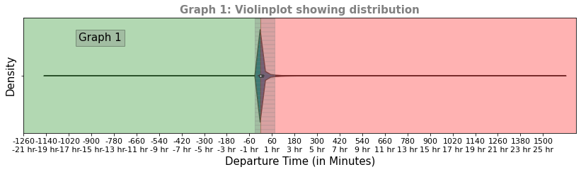

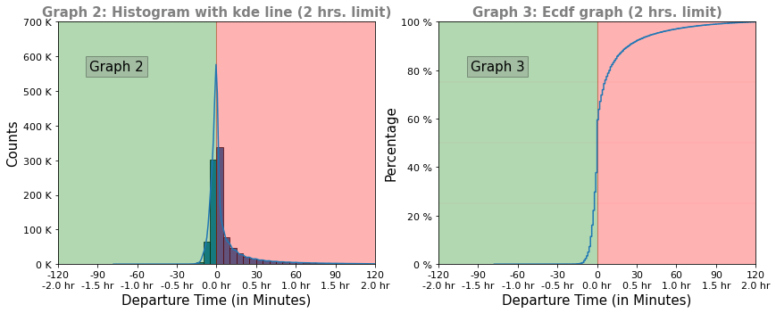

> Note :  
> Graph 1 shows the distribution of full data, Graph 2&3 show a subset of data (2 hours limit), also the bins of Graph 2 histogram are of 5-mins. each.

> Observations :  
> Graph 1 shows a wide range of distribution from (20 hrs. early to 24 hrs. late) but the vast majority of data lies between (0.5 hour early to 1.25 hour late), so further scoping at this range would be beneficial.

> Graph 2 shows normal distribution curve with a slight right-skewed pattern, with peak at (0 to 5 min. late).

## Visualization 9:

## The flights arrival-time distribution

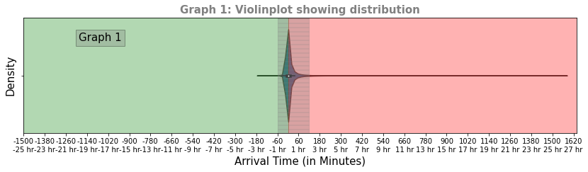

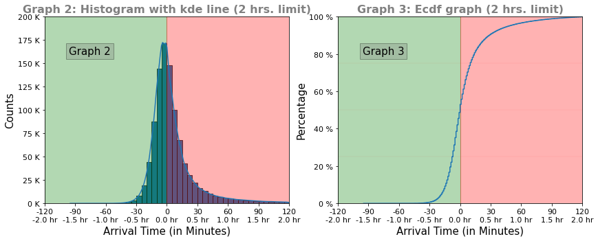

> Note :  
> Graph 1 shows the distribution of full data, Graph 2&3 show a subset of data (2 hours limit),, also the bins of Graph 2 histogram are of 5-mins. each.

> Graph 2 shows normal distribution curve with a slight right-skewed tendency, with peak at (0 to 5 min. early).

> Graph 3 confirms the normal distribution, also shows that flights that arrivea early or at-time are slightly above 50% of the full data.

## Visualization 10:

## The Relation between departure and arrival timing

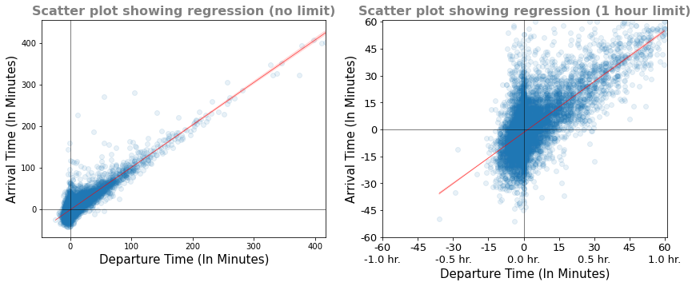

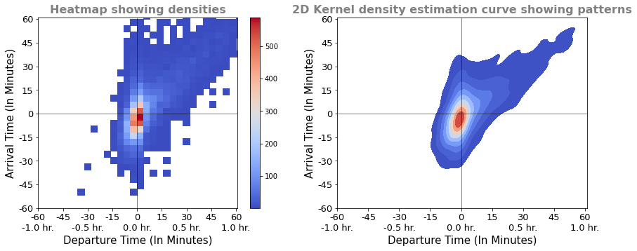

> Note :  
> The Graphs represent a subset of the whole data (1% of full data). Graph 1 shows the relation between departure and arrival timing with no time limit, Graphs 2,3,4 show the same with 1 hour time limit.

> Observations :  
> Graph 1 shows a clear direct proportion wich is predected. the bulk of data ranges between (-15 and +150 mins.) at both axises.

## Visualization 11:

## The Relation between departure and arrival timing through the last 10 years

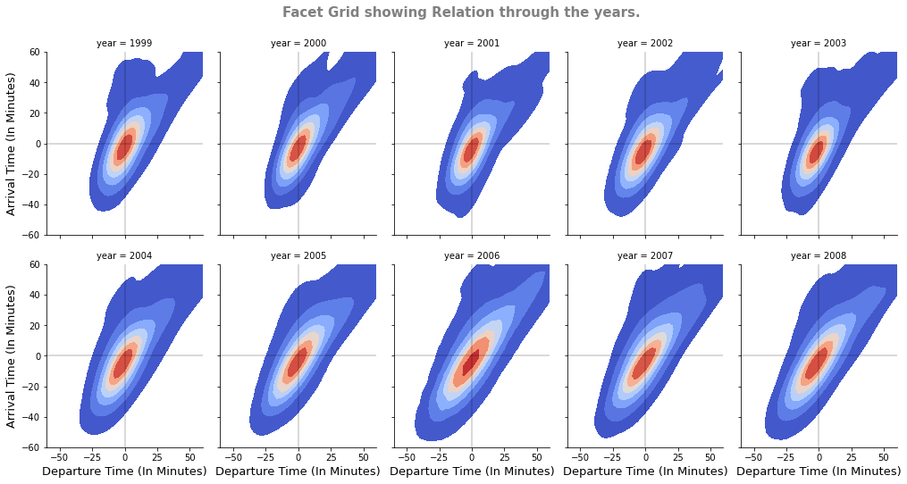

> Observations :  
> Graphs show no significant difference through the years.

## Visualization 12:

## Departure and arrival delaies in average for the top 5 air-lines in the latest years

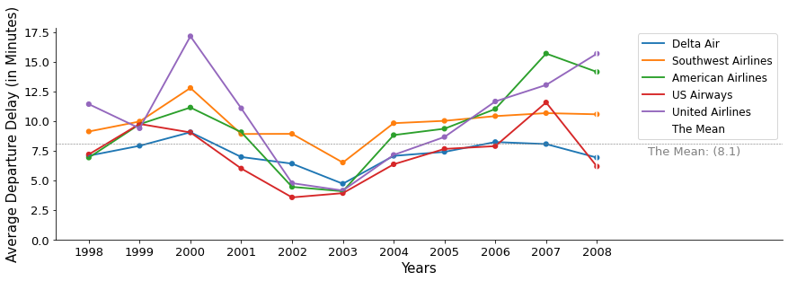

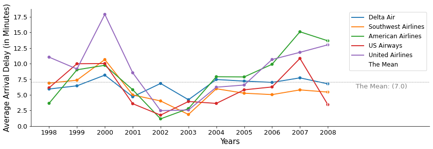

> Observations :  
> Graphs show that Years(2001 to 2004) are the best years with shorter delaies,also a major deterioration in United Airlines in the years (2000) and gradual one at year(2008), while a significant improvement appears in US Airways in the last year(2008).

## Visualization 13:

## Over-all view on reasons of airflights postoning

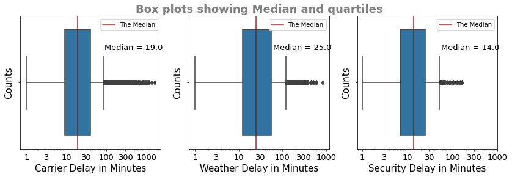

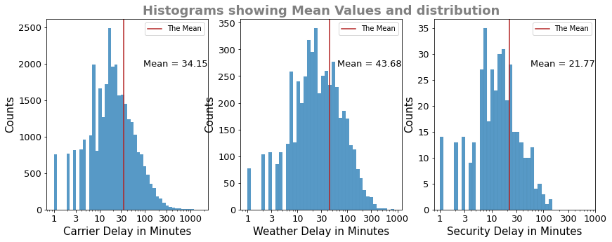

> Note :  
> The Graphs represent data from year(2003) forward because there is no data available before that year.')

> Graphs 2 shows detailed distribution of values and counts, here we observe that carrier delaies are the most common by far while security delaies are the most rare., also it shows a normal distribution pattern with peaks below (30 mins.).

## Visualization 14:

## Reasons for flights postponing through the years

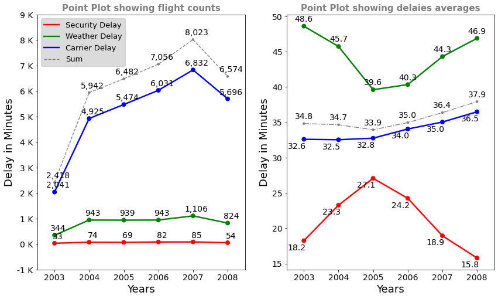

> Note :  
> The Graphs represent data from year(2003) forward because there is no data available before that year.

> Observations :  
> Graph 1 shows that carrier delaies are the most common by far while security delaies are the most rare, also that the number of delaies increase through the years, there is a minor improvement at year(2008)concerning counts.

> Graphs 2 shows the over-all average is very close to the carrier delaies averages which is expected due to their heigher counts, also we observe a major rise in security delaies average at year(2005).